# Starbucks Capstone Challenge

### Introduction

This data set contains simulated data that mimics customer behavior on the Starbucks rewards mobile app. Once every few days, Starbucks sends out an offer to users of the mobile app. An offer can be merely an advertisement for a drink or an actual offer such as a discount or BOGO (buy one get one free). Some users might not receive any offer during certain weeks.

Not all users receive the same offer, and that is the challenge to solve with this data set.

Your task is to combine transaction, demographic and offer data to determine which demographic groups respond best to which offer type. This data set is a simplified version of the real Starbucks app because the underlying simulator only has one product whereas Starbucks actually sells dozens of products.

Every offer has a validity period before the offer expires. As an example, a BOGO offer might be valid for only 5 days. You'll see in the data set that informational offers have a validity period even though these ads are merely providing information about a product; for example, if an informational offer has 7 days of validity, you can assume the customer is feeling the influence of the offer for 7 days after receiving the advertisement.

You'll be given transactional data showing user purchases made on the app including the timestamp of purchase and the amount of money spent on a purchase. This transactional data also has a record for each offer that a user receives as well as a record for when a user actually views the offer. There are also records for when a user completes an offer.

Keep in mind as well that someone using the app might make a purchase through the app without having received an offer or seen an offer.

### Example

To give an example, a user could receive a discount offer buy 10 dollars get 2 off on Monday. The offer is valid for 10 days from receipt. If the customer accumulates at least 10 dollars in purchases during the validity period, the customer completes the offer.

However, there are a few things to watch out for in this data set. Customers do not opt into the offers that they receive; in other words, a user can receive an offer, never actually view the offer, and still complete the offer. For example, a user might receive the "buy 10 dollars get 2 dollars off offer", but the user never opens the offer during the 10 day validity period. The customer spends 15 dollars during those ten days. There will be an offer completion record in the data set; however, the customer was not influenced by the offer because the customer never viewed the offer.

### Cleaning

This makes data cleaning especially important and tricky.

You'll also want to take into account that some demographic groups will make purchases even if they don't receive an offer. From a business perspective, if a customer is going to make a 10 dollar purchase without an offer anyway, you wouldn't want to send a buy 10 dollars get 2 dollars off offer. You'll want to try to assess what a certain demographic group will buy when not receiving any offers.

### Final Advice

Because this is a capstone project, you are free to analyze the data any way you see fit. For example, you could build a machine learning model that predicts how much someone will spend based on demographics and offer type. Or you could build a model that predicts whether or not someone will respond to an offer. Or, you don't need to build a machine learning model at all. You could develop a set of heuristics that determine what offer you should send to each customer (i.e., 75 percent of women customers who were 35 years old responded to offer A vs 40 percent from the same demographic to offer B, so send offer A).

# Data Sets

The data is contained in three files:

- portfolio.json - containing offer ids and meta data about each offer (duration, type, etc.)
- profile.json - demographic data for each customer
- transcript.json - records for transactions, offers received, offers viewed, and offers completed

Here is the schema and explanation of each variable in the files:

**portfolio.json**

- id (string) - offer id
- offer_type (string) - type of offer ie BOGO, discount, informational
- difficulty (int) - minimum required spend to complete an offer
- reward (int) - reward given for completing an offer
- duration (int) - time for offer to be open, in days
- channels (list of strings)

**profile.json**

- age (int) - age of the customer
- became_member_on (int) - date when customer created an app account
- gender (str) - gender of the customer (note some entries contain 'O' for other rather than M or F)
- id (str) - customer id
- income (float) - customer's income

**transcript.json**

- event (str) - record description (ie transaction, offer received, offer viewed, etc.)
- person (str) - customer id
- time (int) - time in hours since start of test. The data begins at time t=0
- value - (dict of strings) - either an offer id or transaction amount depending on the record

**Note:** If you are using the workspace, you will need to go to the terminal and run the command `conda update pandas` before reading in the files. This is because the version of pandas in the workspace cannot read in the transcript.json file correctly, but the newest version of pandas can. You can access the termnal from the orange icon in the top left of this notebook.

You can see how to access the terminal and how the install works using the two images below. First you need to access the terminal:

[figure not shown]

Then you will want to run the above command:

[figure not shown]

Finally, when you enter back into the notebook (use the jupyter icon again), you should be able to run the below cell without any errors.

```python
import pandas as pd
import numpy as np
import math
import json
import matplotlib.pyplot as plt
from datetime import date
% matplotlib inline

from sklearn.preprocessing import MinMaxScaler
from sklearn.metrics import classification_report, mean_absolute_error, mean_squared_error, accuracy_score
from sklearn.multioutput import MultiOutputClassifier
from sklearn.model_selection import train_test_split
from sklearn.tree import DecisionTreeClassifier
from sklearn.naive_bayes import GaussianNB
from sklearn.gaussian_process import GaussianProcessClassifier
from sklearn.neighbors import KNeighborsClassifier
from sklearn.linear_model import LogisticRegression
from sklearn.svm import SVC

# read in the json files
portfolio = pd.read_json('data/portfolio.json', orient='records', lines=True)
profile = pd.read_json('data/profile.json', orient='records', lines=True)
transcript = pd.read_json('data/transcript.json', orient='records', lines=True)
```

## Data Exploration:

In this section I will be exploring the three dataframes porfolio,profile, and transcript. As part of the exploration, I will visualize some details and try to make an initial plan to what I would like to do in each dataframe.

### portfolio dataframe:

```python
# exploring the portfolio dataframe
portfolio.head()
```

|  | channels | difficulty | duration | id | offer_type | reward |
| --- | --- | --- | --- | --- | --- | --- |
| 0 | [email, mobile, social] | 10 | 7 | ae264e3637204a6fb9bb56bc8210ddfd | bogo | 10 |
| 1 | [web, email, mobile, social] | 10 | 5 | 4d5c57ea9a6940dd891ad53e9dbe8da0 | bogo | 10 |
| 2 | [web, email, mobile] | 0 | 4 | 3f207df678b143eea3cee63160fa8bed | informational | 0 |
| 3 | [web, email, mobile] | 5 | 7 | 9b98b8c7a33c4b65b9aebfe6a799e6d9 | bogo | 5 |
| 4 | [web, email] | 20 | 10 | 0b1e1539f2cc45b7b9fa7c272da2e1d7 | discount | 5 |

```
(10, 6)
The describtions of difficulty, duration, and reward
       difficulty   duration     reward
count   10.000000  10.000000  10.000000
mean     7.700000   6.500000   4.200000
std      5.831905   2.321398   3.583915
min      0.000000   3.000000   0.000000
25%      5.000000   5.000000   2.000000
50%      8.500000   7.000000   4.000000
75%     10.000000   7.000000   5.000000
max     20.000000  10.000000  10.000000
```

```
Text(0,0.5,'Count')
```

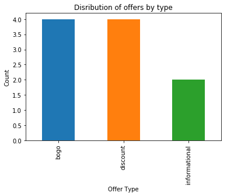

```python
# checking the distribution of offers
print(portfolio.shape)
print("The describtions of difficulty, duration, and reward")
print(portfolio.describe())
portfolio['offer_type'].value_counts().plot(kind='bar')
plt.title("Disribution of offers by type")
plt.xlabel("Offer Type")
plt.ylabel("Count")
```

It seems that we have a total of 10 offers in the portfolio. 4 bogo, 4 discount, and 2 informational.

- There are 4 main channels of communication.
- The difficulty varies between 0 and 20 where 0 is for informational which means that there is no minimum spend required.
- The duration varies between 3 - 10 days
- The rewards vary between 0 and 10. Where 0 is for informational

### profile dataframe:

```python
#exploring profile dataframe
print(profile.shape)
profile.head()
```

```
(17000, 5)
```

|  | age | became_member_on | gender | id | income |
| --- | --- | --- | --- | --- | --- |
| 0 | 118 | 20170212 | None | 68be06ca386d4c31939f3a4f0e3dd783 | NaN |
| 1 | 55 | 20170715 | F | 0610b486422d4921ae7d2bf64640c50b | 112000.0 |
| 2 | 118 | 20180712 | None | 38fe809add3b4fcf9315a9694bb96ff5 | NaN |
| 3 | 75 | 20170509 | F | 78afa995795e4d85b5d9ceeca43f5fef | 100000.0 |
| 4 | 118 | 20170804 | None | a03223e636434f42ac4c3df47e8bac43 | NaN |

It seems that we have a total of 17000 customers in the profile dataframe.

- First let's check if we have any duplicates in the data
  - No duplicates found
- Then we will investigate:
  - Age
  - membership year from became_member_on
  - distribution of gender
  - income average

#### Age:

```python
#checking if we have any duplicated profiles
profile.duplicated().sum()
```

```
0
```

```
count    17000.000000
mean        62.531412
std         26.738580
min         18.000000
25%         45.000000
50%         58.000000
75%         73.000000
max        118.000000
Name: age, dtype: float64
number of unique profiles 17000
number of 118 years old profiles  2175
```

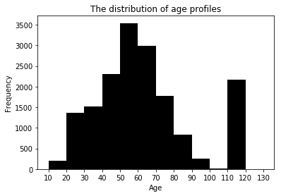

```python
#exploring the distribution of ages
profile['age'].plot(kind='hist',range=(10,130),bins=[10,20,30,40,50,60,70,80,90,100,110,120,130],color='black')
plt.title('The distribution of age profiles')
plt.xlabel('Age')
plt.xticks([10,20,30,40,50,60,70,80,90,100,110,120,130])
print(profile['age'].describe())
print("number of unique profiles", profile['id'].nunique())
print("number of 118 years old profiles ", profile[profile['age']==118].age.count())
```

We don't seem to have any missing age information here.

#### Membership year:

```
The number of missing membership year is  0
```

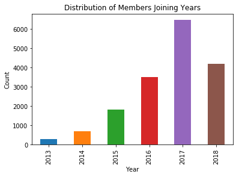

```python
#exploring the became member on
profile['became_member_on'].astype(str).str[:4].value_counts().sort_index().plot(kind='bar')
plt.title("Distribution of Members Joining Years")
plt.xlabel("Year")
plt.ylabel("Count")

#Checking for any missing values
print("The number of missing membership year is ", profile['became_member_on'].isna().sum())
```

```
Text(0,0.5,'Count')
```

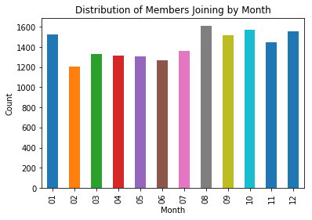

```python
#exploring if there if months actullay differ or almost equally distributed
profile['became_member_on'].astype(str).str[4:6].value_counts().sort_index().plot(kind='bar')
plt.title("Distribution of Members Joining by Month")
plt.xlabel("Month")
plt.ylabel("Count")
```

Most of the users joined in 2017. while the lowest was in 2013. The disribution by month seems realtivly equally disributed.

So The exact date the member joined in is not really important to us. I might need to change it in the cleaning process.

#### Gender:

```
count     14825
unique        3
top           M
freq       8484
Name: gender, dtype: object
The number of females are:  6129
The number of others gender are:  212
We have a total of  2175  that are missing gender information
```

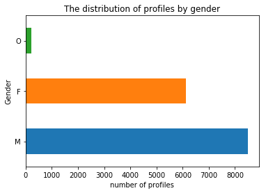

```python
# exploring gender distribution
profile['gender'].value_counts().plot(kind='barh')
plt.title("The distribution of profiles by gender")
plt.ylabel("Gender")
plt.xlabel("number of profiles")
print(profile['gender'].describe())
print("The number of females are: ", profile[profile['gender'] == 'F'].age.count())
print("The number of others gender are: ", profile[profile['gender'] == 'O'].age.count())
print("We have a total of ", profile['gender'].isna().sum(), " that are missing gender information")
```

It seems that we have this breakdwon of genders.

- 8484 males
- 6129 females
- 212 others.

There are a total of 2175 missing gender information. The number matches the 118 years of age that we had earlier. Let's check if they are the same profiles.

```python
# exploring if the missing gender information are the same as the 118 years of age
print("The ages for the missing gender information are :\n", profile[profile['gender'].isna()].age.value_counts())
print("The ages for the missing income information are :\n", profile[profile['gender'].isna()].income.value_counts())
profile[profile['gender'].isna()].head()
```

[output not shown]

|  | age | became_member_on | gender | id | income |
| --- | --- | --- | --- | --- | --- |
| 0 | 118 | 20170212 | None | 68be06ca386d4c31939f3a4f0e3dd783 | NaN |
| 2 | 118 | 20180712 | None | 38fe809add3b4fcf9315a9694bb96ff5 | NaN |
| 4 | 118 | 20170804 | None | a03223e636434f42ac4c3df47e8bac43 | NaN |
| 6 | 118 | 20170925 | None | 8ec6ce2a7e7949b1bf142def7d0e0586 | NaN |
| 7 | 118 | 20171002 | None | 68617ca6246f4fbc85e91a2a49552598 | NaN |

Now it is clear that all members missing gender information also missing income information and have an age of 118 which is an outlier as we noticed earlier. I can safely assume that 118 is the number given to profiles where no age information was available.

profiles aged 118 need to be cleaned

#### Income:

```
count     14825.000000
mean      65404.991568
std       21598.299410
min       30000.000000
25%       49000.000000
50%       64000.000000
75%       80000.000000
max      120000.000000
Name: income, dtype: float64
We have  2175  missing income from the profiles
The number of profiles with minimum income is : 88
The number of profiles with maximum income is : 13
```

```
Text(0,0.5,'Count')
```

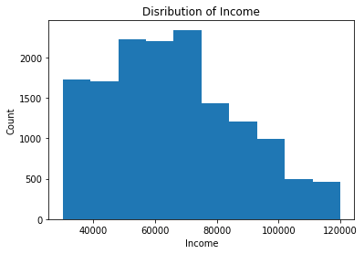

```python
# exploring income discribution
print(profile['income'].describe())
print("We have ",profile['income'].isna().sum()," missing income from the profiles")
print("The number of profiles with minimum income is :", profile[profile['income']== 30000].income.count())
print("The number of profiles with maximum income is :", profile[profile['income']== 120000].income.count())
profile['income'].plot(kind='hist')
plt.title("Disribution of Income")
plt.xlabel("Income")
plt.ylabel("Count")
```

As we knew earlier. 2175 profiles are missing income information.

### Transcript dataframe:

```python
#exploring transcript dataframe
print(transcript.shape)
transcript.head()
```

```
(306534, 4)
```

|  | event | person | time | value |
| --- | --- | --- | --- | --- |
| 0 | offer received | 78afa995795e4d85b5d9ceeca43f5fef | 0 | {'offer id': '9b98b8c7a33c4b65b9aebfe6a799e6d9'} |
| 1 | offer received | a03223e636434f42ac4c3df47e8bac43 | 0 | {'offer id': '0b1e1539f2cc45b7b9fa7c272da2e1d7'} |
| 2 | offer received | e2127556f4f64592b11af22de27a7932 | 0 | {'offer id': '2906b810c7d4411798c6938adc9daaa5'} |
| 3 | offer received | 8ec6ce2a7e7949b1bf142def7d0e0586 | 0 | {'offer id': 'fafdcd668e3743c1bb461111dcafc2a4'} |
| 4 | offer received | 68617ca6246f4fbc85e91a2a49552598 | 0 | {'offer id': '4d5c57ea9a6940dd891ad53e9dbe8da0'} |

It seems that we have a large number of recrods in this dataframe.

- Check if we have any missing values
- Explore the different types of events and their associated value types.
- Check the time maximum value to understand how long were the records collected for
- Explore how many persons were captured in the record. would they be 17000 as in our profile dataframe?

```python
#checking for any missing transcript values
print("The number of missing values in the transcript dataframe is: \n", transcript.isna().sum())
```

```
The number of missing values in the transcript dataframe is:
 event     0
person    0
time      0
value     0
dtype: int64
```

No missing values which is great.

#### event and value:

```
transaction        138953
offer received      76277
offer viewed        57725
offer completed     33579
Name: event, dtype: int64
```

```
Text(0,0.5,'Count')
```

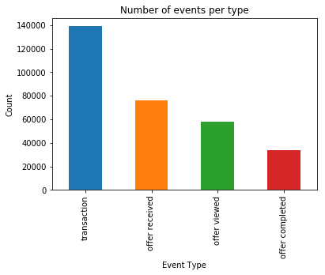

```python
#exploring the events and their types
print(transcript['event'].value_counts())
transcript['event'].value_counts().plot(kind='bar')
plt.title("Number of events per type")
plt.xlabel("Event Type")
plt.ylabel("Count")
```

```python
#what would the value of each event type be like.
print("The value format for transaction is ", transcript[transcript['event']=='transaction'].value.tolist()[0])
print("The value format for offer received is ", transcript[transcript['event']=='offer received'].value.tolist()[0])
print("The value format for offer viewed is ", transcript[transcript['event']=='offer viewed'].value.tolist()[0])
print("The value format for offer completed is ", transcript[transcript['event']=='offer completed'].value.tolist()[0])
```

```
The value format for transaction is  {'amount': 0.8300000000000001}
The value format for offer received is  {'offer id': '9b98b8c7a33c4b65b9aebfe6a799e6d9'}
The value format for offer viewed is  {'offer id': 'f19421c1d4aa40978ebb69ca19b0e20d'}
The value format for offer completed is  {'offer_id': '2906b810c7d4411798c6938adc9daaa5', 'reward': 2}
```

The value is different for each event type:

- Transaction events include amount information
- Offer recieved and offer viewed include offer id informaiton
- Offer completed include offer id and reward amount information

The value column needs to be cleaned and reformatted

#### Person and Time:

```python
# checking the time destribution
print("The time desription is as follows: \n",transcript['time'].describe())
# checking that we have unique people
print("The number of profiles in the person columns is ", transcript['person'].nunique())
```

```
The time desription is as follows:
 count    306534.000000
mean        366.382940
std         200.326314
min           0.000000
25%         186.000000
50%         408.000000
75%         528.000000
max         714.000000
Name: time, dtype: float64
The number of profiles in the person columns is  17000
```

The maximum time is 714 hours which would be around 29.75 days. So it is safe to assume that the records we had were for one month worth of information.

All the profiles have records in the transcript dataframe which include the profiles that have missing information and were recorded as age 118.

These recrods linked to profiles with missing informaiton might need to be removed

## Data Processing

### Portfolio:

```python
#before cleaning
portfolio.head()
```

|  | channels | difficulty | duration | id | offer_type | reward |
| --- | --- | --- | --- | --- | --- | --- |
| 0 | [email, mobile, social] | 10 | 7 | ae264e3637204a6fb9bb56bc8210ddfd | bogo | 10 |
| 1 | [web, email, mobile, social] | 10 | 5 | 4d5c57ea9a6940dd891ad53e9dbe8da0 | bogo | 10 |
| 2 | [web, email, mobile] | 0 | 4 | 3f207df678b143eea3cee63160fa8bed | informational | 0 |
| 3 | [web, email, mobile] | 5 | 7 | 9b98b8c7a33c4b65b9aebfe6a799e6d9 | bogo | 5 |
| 4 | [web, email] | 20 | 10 | 0b1e1539f2cc45b7b9fa7c272da2e1d7 | discount | 5 |

- convert channels to be one column each
- change the duration to be hours
- change the ids to easier ids and rename to customer_id

```python
'''
Clean the portfolio dataframe and return cleaned version. The cleaninign includes:
    *converting channels to be one column each
    *changing the duration to be hours
    *changing the ids to easier ids and rename to customer_id
arguments:
    portfolio: the portfolio dataframe
output:
    portfolio: the cleaned portfolio dataframe
    new_offer_ids: the mapping of old offer ids to new offer ids


'''
def clean_portfolio_df(portfolio):
    # clean portfolio ----- to be converted to method later on.
    #change the duraiton to be hours
    portfolio['duration_hours'] = portfolio['duration'] * 24
    portfolio.drop('duration',inplace=True,axis=1)

    #conver the channels to seperate columns
    portfolio['web'] = portfolio.apply(lambda x:0  if type(x['channels'])==float else (1 if 'web' in x['channels'] else 0) ,axis=1)
    portfolio['email'] = portfolio.apply(lambda x:0  if type(x['channels'])==float else (1 if 'email' in x['channels'] else 0) ,axis=1)
    portfolio['mobile'] = portfolio.apply(lambda x:0  if type(x['channels'])==float else (1 if 'mobile' in x['channels'] else 0) ,axis=1)
    portfolio['social'] = portfolio.apply(lambda x:0  if type(x['channels'])==float else (1 if 'social' in x['channels'] else 0) ,axis=1)
    portfolio.drop('channels',axis=1,inplace=True)

    #change the ids to be easier to read
    old_offer_ids = portfolio['id'].astype('category').cat.categories.tolist()
    new_offer_ids = {x:y for x,y in zip(old_offer_ids,list(range(1,len(old_offer_ids)+1)))}
    portfolio['offer_id'] = portfolio['id'].map(new_offer_ids)
    portfolio.drop('id',axis=1,inplace=True)

    #reorder portfolio
    portfolio = portfolio[['offer_id','offer_type','difficulty','reward','duration_hours','web','email','mobile','social']]

    return portfolio, new_offer_ids


portfolio, new_offer_ids = clean_portfolio_df(portfolio)
```

```python
#after cleanining
portfolio.head()
```

|  | offer_id | offer_type | difficulty | reward | duration_hours | web | email | mobile | social |
| --- | --- | --- | --- | --- | --- | --- | --- | --- | --- |
| 0 | 8 | bogo | 10 | 10 | 168 | 0 | 1 | 1 | 1 |
| 1 | 5 | bogo | 10 | 10 | 120 | 1 | 1 | 1 | 1 |
| 2 | 4 | informational | 0 | 0 | 96 | 1 | 1 | 1 | 0 |
| 3 | 7 | bogo | 5 | 5 | 168 | 1 | 1 | 1 | 0 |
| 4 | 1 | discount | 20 | 5 | 240 | 1 | 1 | 0 | 0 |

### Profile:

```python
#before cleanining
profile.head()
```

|  | age | became_member_on | gender | id | income |
| --- | --- | --- | --- | --- | --- |
| 0 | 118 | 20170212 | None | 68be06ca386d4c31939f3a4f0e3dd783 | NaN |
| 1 | 55 | 20170715 | F | 0610b486422d4921ae7d2bf64640c50b | 112000.0 |
| 2 | 118 | 20180712 | None | 38fe809add3b4fcf9315a9694bb96ff5 | NaN |
| 3 | 75 | 20170509 | F | 78afa995795e4d85b5d9ceeca43f5fef | 100000.0 |
| 4 | 118 | 20170804 | None | a03223e636434f42ac4c3df47e8bac43 | NaN |

- change the ids to readable ids
- change ids column to customer_id
- introduce number of days since joining column
- introduce customer_type (new,regular,loyal)
- introduce year of join
- introduce age group (young_adult,middle_age_adult,old_adult)
- introduce income_range (low,mid,high)
- keep track of the new ids and old ids of the records to drop
- drop 118 years of age records

```python
'''
Clean the profile dataframe by doing the following:
    *change the ids to readable ids
    *change ids column to customer_id
    *introduce number of days since joining column
    *introduce customer_type (new,regular,loyal)
    *introduce year of join
    *introduce age group (young_adult,middle_age_adult,old_adult)
    *introduce income_range (low,mid,high)
    *keep track of the new ids and old ids of the records to drop
    *drop 118 years of age records
arguments:
    profile: profile dataframe
output:
    profile: the cleaned profile dataframe
    deleted_customer_ids: list of deleted customers
    new_customer_ids: mapping of old customer ids to new customer ids


'''

def clean_profile_df(profile):
    #change the ids to readable ids and change column name
    old_customer_ids = profile['id'].astype('category').cat.categories.tolist()
    new_customer_ids = {x:y for x,y in zip(old_customer_ids,list(range(1,len(old_customer_ids)+1)))}
    # profile.replace(new_customer_ids,inplace=True)
    profile['customer_id'] = profile['id'].map(new_customer_ids)
    profile.drop('id',axis=1,inplace=True)
    # profile.rename(columns={'id':'customer_id'},inplace=True)

    #introduce year of join
    profile['year_joined'] = profile['became_member_on'].apply(lambda x:str(x)[:4])
    # introduce number of days since join
    date_today = date(2020,10,15)
    profile['days_as_member'] = profile['became_member_on'].apply(lambda x: date_today -  date(int(str(x)[:4]),
                                                                    int(str(x)[4:6]),int(str(x)[6:])))
    profile['days_as_member'] = profile['days_as_member'].apply(lambda x: x.days)
    #introduce customer type
    profile['customer_type'] = profile['days_as_member'].apply(lambda x: 'new' if x < 1095 else
                                                               ('regular' if x < 2190 else 'loyal'))
    profile.drop('became_member_on',axis=1,inplace=True)
    # introduce age group
    profile['age_group'] = profile['age'].apply(lambda x: 'young_adult' if x < 40 else
                                                ('middle_age' if x < 60 else 'old'))
    # introduce income range
    profile['income_range'] = profile['income'].apply(lambda x: 'low' if x < 65000 else
                                                      ('mid' if x < 100000 else 'high'))
    #keep track of deleted ids
    deleted_customer_ids = profile[profile['age'] == 118].customer_id.tolist()
    profile.drop(profile.loc[profile['age'] == 118].index,axis=0,inplace=True)

    #reorder columns
    profile = profile[['customer_id','gender','age','age_group','income','income_range','year_joined'
                       ,'days_as_member','customer_type']]

    return profile,deleted_customer_ids,new_customer_ids

profile,deleted_customer_ids,new_customer_ids= clean_profile_df(profile)
```

```python
#after cleaning
profile.head()
```

|  | customer_id | gender | age | age_group | income | income_range | year_joined | days_as_member | customer_type |
| --- | --- | --- | --- | --- | --- | --- | --- | --- | --- |
| 1 | 399 | F | 55 | middle_age | 112000.0 | high | 2017 | 1188 | regular |
| 3 | 7997 | F | 75 | old | 100000.0 | high | 2017 | 1255 | regular |
| 5 | 15044 | M | 68 | old | 70000.0 | mid | 2018 | 903 | new |
| 8 | 3729 | M | 65 | old | 53000.0 | low | 2018 | 979 | new |
| 12 | 3060 | M | 58 | middle_age | 51000.0 | low | 2017 | 1069 | new |

### Transcript:

```python
#before cleanining
transcript.head()
```

|  | event | person | time | value |
| --- | --- | --- | --- | --- |
| 0 | offer received | 78afa995795e4d85b5d9ceeca43f5fef | 0 | {'offer id': '9b98b8c7a33c4b65b9aebfe6a799e6d9'} |
| 1 | offer received | a03223e636434f42ac4c3df47e8bac43 | 0 | {'offer id': '0b1e1539f2cc45b7b9fa7c272da2e1d7'} |
| 2 | offer received | e2127556f4f64592b11af22de27a7932 | 0 | {'offer id': '2906b810c7d4411798c6938adc9daaa5'} |
| 3 | offer received | 8ec6ce2a7e7949b1bf142def7d0e0586 | 0 | {'offer id': 'fafdcd668e3743c1bb461111dcafc2a4'} |
| 4 | offer received | 68617ca6246f4fbc85e91a2a49552598 | 0 | {'offer id': '4d5c57ea9a6940dd891ad53e9dbe8da0'} |

- change person to customer id using new customer_ids
- extract value to seperate columns (offer_id,reward,amount)
- change offer_ids to the new ids
- drop rows that are irrelevant since the customers were deleted
- work on finding
  - for each customer - how many was spent to complete offers and how much was not offer related
  - which offers were received viewed and completed
  - which offers were just viewed
  - which offers were copmleted before viewing them

```python
'''
Clean the transcript dataframe by doing the following:
    *change person to customer id using new customer_ids
    *extract value to seperate columns (offer_id,reward,amount)
    *change offer_ids to the new ids
    *drop rows that are irrelevant since the customers were deleted
    *work on finding


arguments:
    transcript: transcript dataframe
    portfolio: portfolio dataframe
    new_customer_ids: mapping of old customer ids to new customer ids
    deleted_customer_ids: list of deleted customers
    new_offer_ids: mapping of old offer ids to new offer ids

output:
    transcript: cleaned transcript dataframe

'''


def clean_transcript_df(transcript = transcript,portfolio = portfolio,new_customer_ids = new_customer_ids
                        ,deleted_customer_ids = deleted_customer_ids,new_offer_ids = new_offer_ids):
    #change the person to readable customer ids and change column name
    # transcript.replace(new_customer_ids,inplace=True)
    transcript['customer_id'] = transcript['person'].map(new_customer_ids)
    transcript.drop('person',axis=1,inplace=True)

    # work on extracting the value column to seperate columns
    offers_ids           = transcript[transcript['event'].isin(['offer received','offer viewed'])].index.tolist()
    offers_completed_ids = transcript[transcript['event'] == 'offer completed'].index.tolist()
    transactions_ids     = transcript[transcript['event'] == 'transaction'].index.tolist()

    #add offer_id reward_recieved and amount spent columns
    transcript['offer id recieved and viewed'] = transcript.loc[offers_ids]['value'].apply(lambda x: x['offer id'])
    transcript['offer id completed'] = transcript.loc[offers_completed_ids]['value'].apply(lambda x: x['offer_id'])
    transcript['reward_received']   = transcript.loc[offers_completed_ids]['value'].apply(lambda x: x['reward'])
    transcript['amount'] = transcript.loc[transactions_ids]['value'].apply(lambda x: x['amount'])
    transcript['offer_id'] = transcript['offer id recieved and viewed'].fillna(transcript['offer id completed'])
    transcript.drop('offer id recieved and viewed',axis=1,inplace=True)
    transcript.drop('offer id completed',axis=1,inplace=True)
    transcript.drop('value',axis=1,inplace=True)

    #change the offer_ids to readable customer ids and change column name
    transcript['offer_id'] = transcript['offer_id'].map(new_offer_ids)

    #append offer_type to transcript dataframe
    transcript = pd.merge(transcript,portfolio[['offer_id','offer_type','duration_hours']],
                          how='left',left_on='offer_id',right_on='offer_id')

    #add offer_received_count offer_viewed_count and offer_completed_count
    transcript['offer_received_count']= np.nan
    transcript['offer_viewed_count']= np.nan
    transcript['offer_completed_count'] = np.nan
    transcript['offer_viewed_after_completion'] = np.nan

    return transcript


#Clean the transcript
transcript = clean_transcript_df()
```

```python
#after cleanining
transcript.head()
```

|  | event | time | customer_id | reward_received | amount | offer_id | offer_type | duration_hours | offer_received_count | offer_viewed_count | offer_completed_count | offer_viewed_after_completion |
| --- | --- | --- | --- | --- | --- | --- | --- | --- | --- | --- | --- | --- |
| 0 | offer received | 0 | 7997 | NaN | NaN | 7.0 | bogo | 168.0 | NaN | NaN | NaN | NaN |
| 1 | offer received | 0 | 10736 | NaN | NaN | 1.0 | discount | 240.0 | NaN | NaN | NaN | NaN |
| 2 | offer received | 0 | 15044 | NaN | NaN | 3.0 | discount | 168.0 | NaN | NaN | NaN | NaN |
| 3 | offer received | 0 | 9525 | NaN | NaN | 10.0 | discount | 240.0 | NaN | NaN | NaN | NaN |
| 4 | offer received | 0 | 6940 | NaN | NaN | 5.0 | bogo | 120.0 | NaN | NaN | NaN | NaN |

**The following cell will calculate money spent for offers and money spent without offers and will count how many time each customer recieved an offer , viewed it, and completed it**

This cell will take some time to run

```python
'''
process the transcript dataframe to calculate the following:
*for each customer - how much was spent to complete offers and how much was not offer related
        which offers were received viewed and completed
        which offers were just viewed
        which offers were copmleted before viewing them

arguments:
    transcript: the transcript dataframe

output:
    transcript: transcript after processing
    money_spent_for_offers_dict: dictionary of the money spent to complete offers per user
    money_spent_without_offers_dict: dicitonary of the money spent not related to any offer per user

'''

def process_transcript_df(transcript):
    #create the dictionaries needed to cover money spent
    money_spent_for_offers_dict = dict()
    money_spent_without_offers_dict = dict()

    for customer in transcript['customer_id'].unique():
        money_spent_no_offer = 0
        money_spent_post_offer = 0
        customer_df = transcript[transcript['customer_id'] == customer]
        # The customer did not recieve any offers
        if len(customer_df[customer_df['event'] == 'offer received'] ) <1:
            money_spent_no_offer = customer_df['amount'].sum()
            money_spent_without_offers_dict[customer] = money_spent_no_offer


        # The customer recieved at least one offer
        else :
            # get the indicies of the offer and offer ids recieved
            offer_ids = customer_df[customer_df['event'] == 'offer received'].offer_id
            offer_indecies = customer_df[customer_df['event'] == 'offer received'].index
            #create dictionaries to keep track of offers recieved viewed, viewed after completion, and completed
            offer_received_dict = dict()
            offer_viewed_dict = dict()
            offer_viewed_not_counted = dict()
            offer_completed_dict = dict()
            #this dict will keep track of the validity of each offer
            offer_limit_dict = dict()
            #set offer_recieved offer_viewed offer_completed to zeros
            for offer in offer_ids:
                offer_received_dict[offer] = 0
                offer_viewed_dict[offer] = 0
                offer_viewed_not_counted[offer]=0
                offer_completed_dict[offer] = 0
                #set offer_duration and offer_time to -1 if there is no offer
                offer_limit_dict[offer] = -1


            #loop over the customer rows
            for index,row in customer_df.iterrows():
                # check if this is a transaction
                if row['event'] == 'transaction':
                    # no offer is viewed hence the amount is spent without knowledge of offers
                    if(all(value == 0 for value in offer_viewed_dict.values())):
                        money_spent_no_offer += row['amount']
                    # all offers are already completed hence money spent is not realted to offers
                    elif (offer_completed_dict == offer_viewed_dict):
                        money_spent_no_offer += row['amount']
                    # the offers are already expired (passed their timelimit)
                    elif ((np.array(list(offer_limit_dict.values())) > row['time']).sum() == 0):
                        money_spent_no_offer += row['amount']
                    # This spending is within offer timelimit
                    else:
                        money_spent_post_offer += row['amount']

                # the offer recieved case
                elif row['event'] == 'offer received':
                    offer_received_dict[row['offer_id']] += 1
                    # capture the timelimit of the offer
                    offer_limit_dict[row['offer_id']] = row['time'] + row['duration_hours']

                # the offer viewed case
                elif row['event'] == 'offer viewed':
                    # the condition where offer is completed without viewing it
                    if(offer_completed_dict[row['offer_id']] > offer_viewed_dict[row['offer_id']]):
                        offer_viewed_not_counted[row['offer_id']] += 1
                    # the condition where offer is viewed after expiry of offer validity
                    elif(offer_viewed_dict[row['offer_id']] > offer_limit_dict[row['offer_id']]):
                        offer_viewed_not_counted[row['offer_id']] += 1
                    # count the offer is viewed
                    else:
                        offer_viewed_dict[row['offer_id']] += 1

                # the offer completed case
                elif row['event'] == 'offer completed':
                    offer_completed_dict[row['offer_id']] += 1

            #add money spent to dictionaries. this will be used later to see how much customer
            #spent pre and post offers
            money_spent_without_offers_dict[customer] = money_spent_no_offer
            money_spent_for_offers_dict[customer] =  money_spent_post_offer

            for offer_index in offer_indecies:
                # add the offer count to the dataframe
                offer_id = customer_df.loc[offer_index,'offer_id']
                transcript.at[offer_index,'offer_received_count'] = offer_received_dict[offer_id]
                transcript.at[offer_index,'offer_viewed_count'] = offer_viewed_dict[offer_id]
                transcript.at[offer_index,'offer_completed_count'] = offer_completed_dict[offer_id]
                transcript.at[offer_index,'offer_viewed_after_completion'] = offer_viewed_not_counted[offer_id]

    return transcript,money_spent_for_offers_dict,money_spent_without_offers_dict

#process the transcript dataframe and assign it to df to keep the transcript for reference
df,money_spent_for_offers_dict,money_spent_without_offers_dict = process_transcript_df(transcript)
```

```python
'''
clean the transcript further after processing renaming some columns and dropping irrelevant ones and deleting
all rows releted to deleted customer ids.

argument:
    df: the processed transcript dataframe
    deleted_customer_ids: the list of deleted customers

output:
    df: the cleaned and processed transcript dataframe

'''

def clean_transcript_post_processing(df=df,deleted_customer_ids=deleted_customer_ids):
    # creating a new dataframe to analyze from the transcript dataframe
    df = df[df['event'] == 'offer received']
    df.drop_duplicates(subset=['customer_id','offer_id'],inplace=True)
    df.rename(columns={'offer_received_count':'received','offer_viewed_count':'viewed',
                       'offer_completed_count':'completed','offer_viewed_after_completion':'viewed_late',
                       'reward_received':'reward'},inplace=True)
    df.drop(['event','time','amount','reward','offer_type','duration_hours'],axis=1,inplace=True)
    df = df[['customer_id','offer_id','received','viewed','completed','viewed_late']]
    #drop the customers that do not have any information about (the 118 years of age)
    df = df[~ df['customer_id'].isin(deleted_customer_ids)]
    return df

df = clean_transcript_post_processing()
```

```python
#Dataframe after processing for one more time
df.head()
```

|  | customer_id | offer_id | received | viewed | completed | viewed_late |
| --- | --- | --- | --- | --- | --- | --- |
| 0 | 7997 | 7.0 | 1.0 | 1.0 | 1.0 | 0.0 |
| 2 | 15044 | 3.0 | 1.0 | 1.0 | 0.0 | 0.0 |
| 5 | 3729 | 9.0 | 2.0 | 2.0 | 2.0 | 0.0 |
| 7 | 3060 | 4.0 | 1.0 | 0.0 | 0.0 | 0.0 |
| 8 | 11411 | 1.0 | 1.0 | 1.0 | 0.0 | 0.0 |

```python
# create a df_master which contains all information from profile and portfolio to use for data analysis
df_master = pd.merge(df,profile,how='left',left_on='customer_id',right_on='customer_id')
df_master = pd.merge(df_master,portfolio,how='left',left_on='offer_id',right_on='offer_id')
```

```python
df_master.head()
```

|  | customer_id | offer_id | received | viewed | completed | viewed_late | gender | age | age_group | income | ... | days_as_member | customer_type | offer_type | difficulty | reward | duration_hours | web | email | mobile | social |
| --- | --- | --- | --- | --- | --- | --- | --- | --- | --- | --- | --- | --- | --- | --- | --- | --- | --- | --- | --- | --- | --- |
| 0 | 7997 | 7.0 | 1.0 | 1.0 | 1.0 | 0.0 | F | 75 | old | 100000.0 | ... | 1255 | regular | bogo | 5 | 5 | 168 | 1 | 1 | 1 | 0 |
| 1 | 15044 | 3.0 | 1.0 | 1.0 | 0.0 | 0.0 | M | 68 | old | 70000.0 | ... | 903 | new | discount | 10 | 2 | 168 | 1 | 1 | 1 | 0 |
| 2 | 3729 | 9.0 | 2.0 | 2.0 | 2.0 | 0.0 | M | 65 | old | 53000.0 | ... | 979 | new | bogo | 5 | 5 | 120 | 1 | 1 | 1 | 1 |
| 3 | 3060 | 4.0 | 1.0 | 0.0 | 0.0 | 0.0 | M | 58 | middle_age | 51000.0 | ... | 1069 | new | informational | 0 | 0 | 96 | 1 | 1 | 1 | 0 |
| 4 | 11411 | 1.0 | 1.0 | 1.0 | 0.0 | 0.0 | F | 61 | old | 57000.0 | ... | 1130 | regular | discount | 20 | 5 | 240 | 1 | 1 | 0 | 0 |

5 rows × 22 columns

## Data Analysis:

**How many offers were recieved, viewed, and completed for each offer_type?**

| offer_type | received | viewed | completed | viewed_late |
| --- | --- | --- | --- | --- |
| bogo | 26537.0 | 19484.0 | 15258.0 | 2555.0 |
| discount | 26664.0 | 16300.0 | 17186.0 | 2161.0 |
| informational | 13300.0 | 9360.0 | 0.0 | 0.0 |

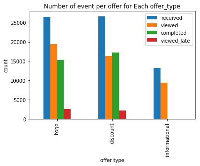

```python
# analyse how many data were received, viewed, and completed for each type
df2 = df_master[['offer_type','received','viewed','completed','viewed_late']]
df2 = df2.groupby('offer_type').sum()
df2.plot(kind='bar')
plt.title("Number of event per offer for Each offer_type")
plt.xlabel("offer type")
plt.ylabel("count")
df2.head()
```

| gender | received | viewed | completed | viewed_late |
| --- | --- | --- | --- | --- |
| F | 10975.0 | 7881.0 | 7501.0 | 1262.0 |
| M | 15208.0 | 11324.0 | 7512.0 | 1257.0 |

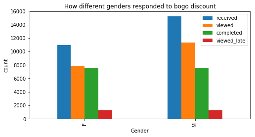

```python
#investigate how different genders dealt reacted to offers recieved
df2 = df_master[['offer_type','gender','received','viewed','completed','viewed_late']]
df2 = df2[(df2['offer_type']=='bogo') & (df2['gender'] !='O')]
df2 = df2.drop('offer_type',axis=1)
df2 = df2.groupby('gender').sum()
df2.plot(kind='bar',figsize=(8,4))
plt.title("How different genders responded to bogo discount")
plt.xlabel("Gender")
plt.ylabel("count")
df2.head()
```

| income_range | customer_type | received | viewed | completed | viewed_late |
| --- | --- | --- | --- | --- | --- |
| high | loyal | 7.0 | 4.0 | 6.0 | 2.0 |
|  | new | 397.0 | 249.0 | 242.0 | 64.0 |
|  | regular | 954.0 | 618.0 | 762.0 | 105.0 |
| low | loyal | 220.0 | 175.0 | 88.0 | 8.0 |
|  | new | 1636.0 | 1272.0 | 725.0 | 129.0 |
|  | regular | 2570.0 | 1869.0 | 1873.0 | 316.0 |
| mid | loyal | 121.0 | 90.0 | 80.0 | 12.0 |
|  | new | 1764.0 | 1316.0 | 999.0 | 180.0 |
|  | regular | 3306.0 | 2288.0 | 2726.0 | 446.0 |

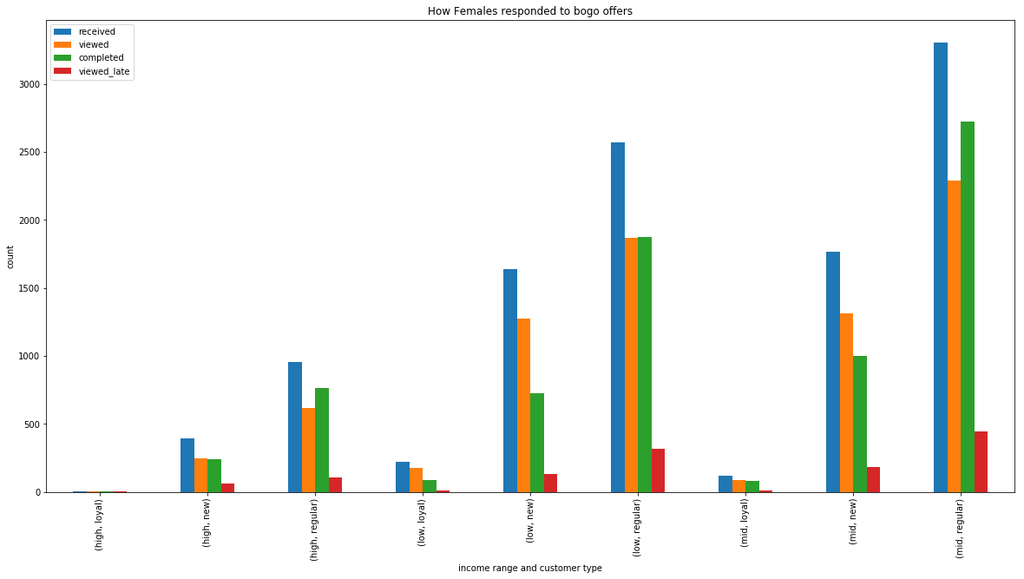

```python
#explore how females reacted to differnt offers - the details are based on income range and customer type
df2 = df_master[['offer_type','gender','income_range','customer_type','received','viewed','completed','viewed_late']]
df2 = df2[(df2['gender'] == 'F') & (df2['offer_type'] == 'bogo')]
df2 = df2.drop(['offer_type','gender'],axis=1)
df2 = df2.groupby(['income_range','customer_type']).sum()
df2.plot(kind='bar',figsize=(20,10))
plt.title("How Females responded to bogo offers")
plt.xlabel("income range and customer type")
plt.ylabel("count")
df2
```

| income_range | customer_type | received | viewed | completed | viewed_late |
| --- | --- | --- | --- | --- | --- |
| high | new | 183.0 | 118.0 | 120.0 | 16.0 |
|  | regular | 448.0 | 285.0 | 375.0 | 60.0 |
| low | loyal | 735.0 | 574.0 | 236.0 | 37.0 |
|  | new | 3802.0 | 2892.0 | 1055.0 | 156.0 |
|  | regular | 4508.0 | 3318.0 | 2333.0 | 410.0 |

[figure not shown]

```python
#analysing how males reacted to bogos - the details are based on income range and customer type
df2 = df_master[['offer_type','gender','income_range','customer_type','received','viewed','completed','viewed_late']]
df2 = df2[(df2['offer_type']=='bogo') & (df2['gender'] == 'M')]
df2 = df2.drop(['offer_type','gender'],axis=1)
df2 = df2.groupby(['income_range','customer_type']).sum()
df2.plot(kind='bar',figsize=(10,10))
plt.title("How Males responded to bogo offers")
plt.xlabel("income range and customer type")
plt.ylabel("count")
df2.head()
```

| income_range | customer_type | received | viewed | completed | viewed_late |
| --- | --- | --- | --- | --- | --- |
| high | loyal | 2.0 | 2.0 | 2.0 | 0.0 |
|  | new | 366.0 | 190.0 | 246.0 | 37.0 |
|  | regular | 955.0 | 490.0 | 798.0 | 111.0 |
| low | loyal | 196.0 | 122.0 | 130.0 | 10.0 |
|  | new | 1639.0 | 1008.0 | 828.0 | 124.0 |

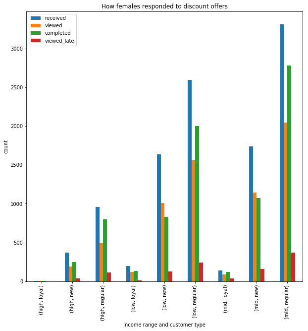

```python
##analysing how females reacted to discount - the details are based on income range and customer type
df2 = df_master[['offer_type','gender','income_range','customer_type','received','viewed','completed','viewed_late']]
df2 = df2[(df2['offer_type']=='discount') & (df2['gender'] == 'F')]
df2 = df2.drop(['offer_type','gender'],axis=1)
df2 = df2.groupby(['income_range','customer_type']).sum()
df2.plot(kind='bar',figsize=(10,10))
plt.title("How females responded to discount offers")
plt.xlabel("income range and customer type")
plt.ylabel("count")
df2.head()
```

| income_range | customer_type | received | viewed | completed | viewed_late |
| --- | --- | --- | --- | --- | --- |
| high | new | 182.0 | 91.0 | 120.0 | 14.0 |
|  | regular | 453.0 | 224.0 | 389.0 | 62.0 |
| low | loyal | 729.0 | 435.0 | 434.0 | 16.0 |
|  | new | 4071.0 | 2388.0 | 1358.0 | 147.0 |
|  | regular | 4324.0 | 2570.0 | 2807.0 | 304.0 |

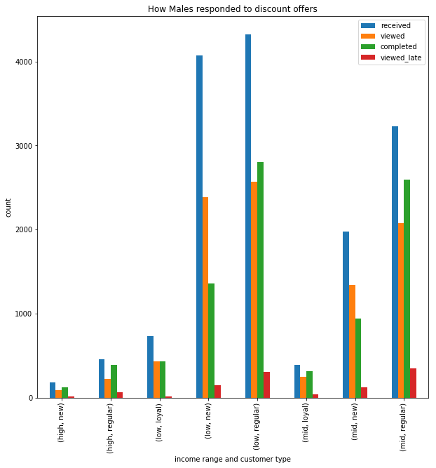

```python
#analysing how males reacted to discount - the details are based on income range and customer type
df2 = df_master[['offer_type','gender','income_range','customer_type','received','viewed','completed','viewed_late']]
df2 = df2[(df2['offer_type']=='discount') & (df2['gender'] == 'M')]
df2 = df2.drop(['offer_type','gender'],axis=1)
df2 = df2.groupby(['income_range','customer_type']).sum()
df2.plot(kind='bar',figsize=(10,10))
plt.title("How Males responded to discount offers")
plt.xlabel("income range and customer type")
plt.ylabel("count")
df2.head()
```

| offer_type | income_range | received | viewed | completed | viewed_late |
| --- | --- | --- | --- | --- | --- |
| bogo | high | 1992.0 | 1276.0 | 1508.0 | 248.0 |
|  | low | 13658.0 | 10238.0 | 6429.0 | 1074.0 |
|  | mid | 10887.0 | 7970.0 | 7321.0 | 1233.0 |
| discount | high | 1960.0 | 999.0 | 1557.0 | 224.0 |
|  | low | 13758.0 | 8215.0 | 7690.0 | 856.0 |

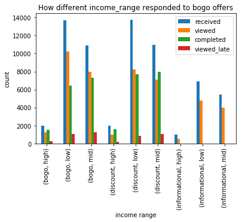

```python
#analyse how different income_ranges are related to bogo offers
df2 = df_master[['offer_type','income_range','received','viewed','completed','viewed_late']]
# df2 = df2[df2['offer_type']=='bogo']
# df2 = df2.drop('offer_type',axis=1)
df2 = df2.groupby(['offer_type','income_range']).sum()
df2.plot(kind='bar')
plt.title("How different income_range responded to bogo offers")
plt.xlabel("income range")
plt.ylabel("count")
df2.head()
```

| offer_type | customer_type | received | viewed | completed | viewed_late |
| --- | --- | --- | --- | --- | --- |
| bogo | loyal | 1456.0 | 1138.0 | 637.0 | 92.0 |
|  | new | 9886.0 | 7448.0 | 4043.0 | 727.0 |
|  | regular | 15195.0 | 10898.0 | 10578.0 | 1736.0 |
| discount | loyal | 1466.0 | 907.0 | 1004.0 | 98.0 |
|  | new | 10130.0 | 6287.0 | 4654.0 | 610.0 |
|  | regular | 15068.0 | 9106.0 | 11528.0 | 1453.0 |

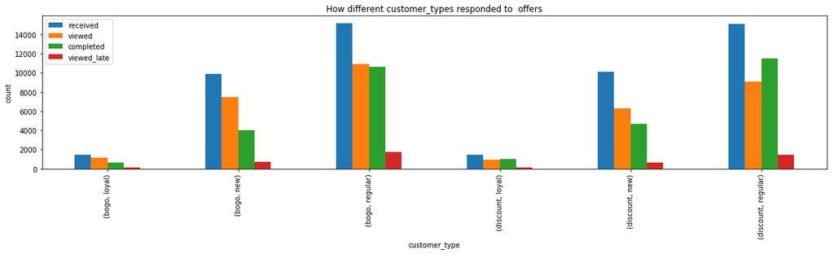

```python
# analyse how different customer types react to bogo offers
df2 = df_master[['offer_type','customer_type','received','viewed','completed','viewed_late']]
df2 = df2[df2['offer_type']!='informational']
# df2 = df2.drop('offer_type',axis=1)
df2 = df2.groupby(['offer_type','customer_type']).sum()
df2.plot(kind='bar',figsize=(20,4))
plt.title("How different customer_types responded to  offers")
plt.xlabel("customer_type")
plt.ylabel("count")
df2
```

| gender | received | viewed | completed | viewed_late |
| --- | --- | --- | --- | --- |
| F | 10943.0 | 6651.0 | 7976.0 | 1082.0 |
| M | 15354.0 | 9381.0 | 8954.0 | 1050.0 |

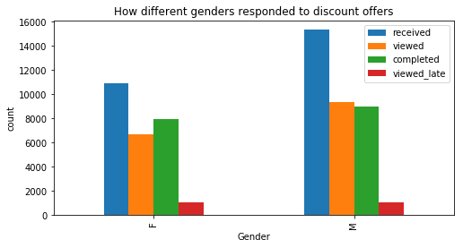

```python
# analyse how different genders react to discount offers
df2 = df_master[['offer_type','gender','received','viewed','completed','viewed_late']]
df2 = df2[(df2['offer_type']=='discount') & (df2['gender']!='O')]
df2 = df2.drop('offer_type',axis=1)
df2 = df2.groupby('gender').sum()
df2.plot(kind='bar',figsize=(8,4))
plt.title("How different genders responded to discount offers")
plt.xlabel("Gender")
plt.ylabel("count")
df2.head()
```

| offer_type | income_range | received | viewed | completed | viewed_late |
| --- | --- | --- | --- | --- | --- |
| bogo | high | 1992.0 | 1276.0 | 1508.0 | 248.0 |
|  | low | 13658.0 | 10238.0 | 6429.0 | 1074.0 |
|  | mid | 10887.0 | 7970.0 | 7321.0 | 1233.0 |
| discount | high | 1960.0 | 999.0 | 1557.0 | 224.0 |
|  | low | 13758.0 | 8215.0 | 7690.0 | 856.0 |
|  | mid | 10946.0 | 7086.0 | 7939.0 | 1081.0 |

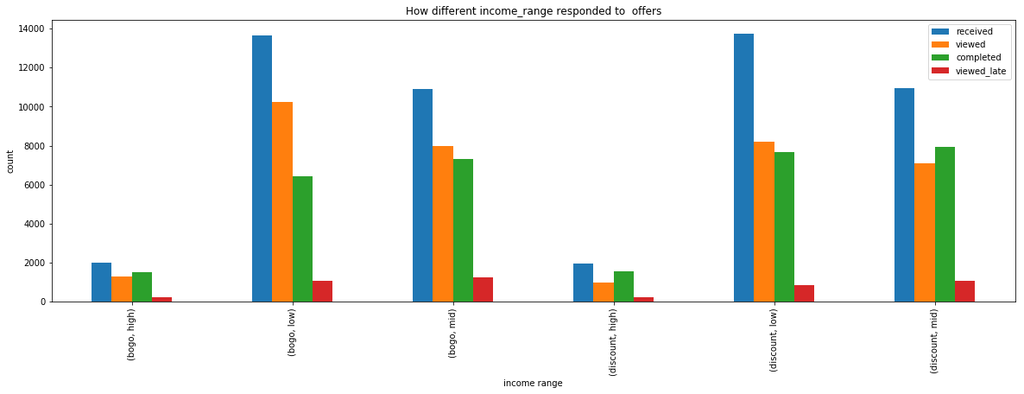

```python
# analyse how different income range react to  offers
df2 = df_master[['offer_type','income_range','received','viewed','completed','viewed_late']]
df2 = df2[df2['offer_type']!='informational' ]
# df2 = df2.drop('offer_type',axis=1)
df2 = df2.groupby(['offer_type','income_range']).sum()
df2.plot(kind='bar',figsize=(20,6))
plt.title("How different income_range responded to  offers")
plt.xlabel("income range")
plt.ylabel("count")
df2
```

| customer_type | received | viewed | completed | viewed_late |
| --- | --- | --- | --- | --- |
| loyal | 1466.0 | 907.0 | 1004.0 | 98.0 |
| new | 10130.0 | 6287.0 | 4654.0 | 610.0 |
| regular | 15068.0 | 9106.0 | 11528.0 | 1453.0 |

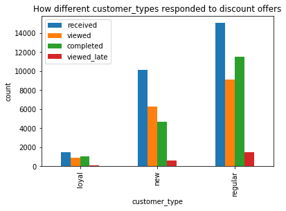

```python
# analyse how different customer types react to discount offers
df2 = df_master[['offer_type','customer_type','received','viewed','completed','viewed_late']]
df2 = df2[df2['offer_type']=='discount']
df2 = df2.drop('offer_type',axis=1)
df2 = df2.groupby('customer_type').sum()
df2.plot(kind='bar')
plt.title("How different customer_types responded to discount offers")
plt.xlabel("customer_type")
plt.ylabel("count")
df2.head()
```

**How many offers were recieved, viewed, and completed for each age group?**

| age_group | received | viewed | completed | viewed_late |
| --- | --- | --- | --- | --- |
| middle_age | 26182.0 | 18244.0 | 13131.0 | 1875.0 |
| old | 26331.0 | 17835.0 | 13598.0 | 2017.0 |
| young_adult | 13988.0 | 9065.0 | 5715.0 | 824.0 |

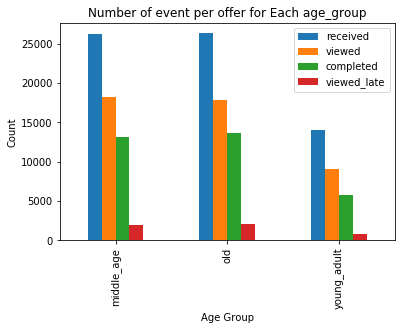

```python
# analyse how different age groups react to offers
df2 = df_master[['age_group','received','viewed','completed','viewed_late']]
df2 = df2.groupby('age_group').sum()
df2.plot(kind='bar')
plt.title("Number of event per offer for Each age_group")
plt.xlabel("Age Group")
plt.ylabel("Count")
df2.head()
```

**How many offers were recieved, viewed, and completed for each gender group?**

| gender | received | viewed | completed | viewed_late |
| --- | --- | --- | --- | --- |
| F | 27456.0 | 18442.0 | 15477.0 | 2344.0 |
| M | 38129.0 | 25994.0 | 16466.0 | 2307.0 |
| O | 916.0 | 708.0 | 501.0 | 65.0 |

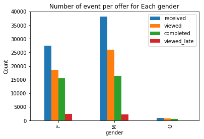

```python
#explore how different genders react to offers
df2 = df_master[['gender','received','viewed','completed','viewed_late']]
df2 = df2.groupby('gender').sum()
df2.plot(kind='bar')
plt.title("Number of event per offer for Each gender")
plt.xlabel("gender")
plt.ylabel("Count")
df2.head()
```

**How many offers were recieved, viewed, and completed for each customer_type?**

| customer_type | received | viewed | completed | viewed_late |
| --- | --- | --- | --- | --- |
| loyal | 3663.0 | 2565.0 | 1641.0 | 190.0 |
| new | 24989.0 | 17156.0 | 8697.0 | 1337.0 |
| regular | 37849.0 | 25423.0 | 22106.0 | 3189.0 |

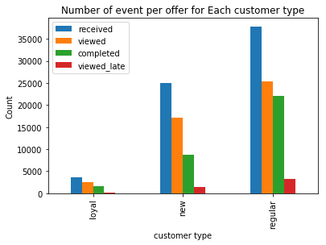

```python
#analyse how different customer types reacted to offers
df2 = df_master[['customer_type','received','viewed','completed','viewed_late']]
df2 = df2.groupby('customer_type').sum()
df2.plot(kind='bar')
plt.title("Number of event per offer for Each customer type")
plt.xlabel("customer type")
plt.ylabel("Count")
df2.head()
```

**How many offers were recieved, viewed, and completed for each income_range?**

| income_range | received | viewed | completed | viewed_late |
| --- | --- | --- | --- | --- |
| high | 4918.0 | 2832.0 | 3065.0 | 472.0 |
| low | 34336.0 | 23253.0 | 14119.0 | 1930.0 |
| mid | 27247.0 | 19059.0 | 15260.0 | 2314.0 |

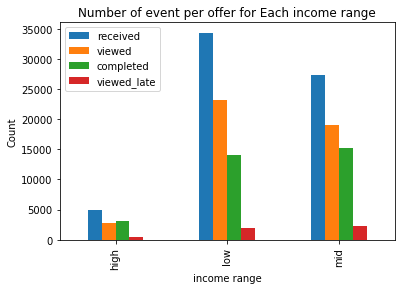

```python
#explore how different income ranges reacted to offers
df2 = df_master[['income_range','received','viewed','completed','viewed_late']]
df2 = df2.groupby('income_range').sum()
df2.plot(kind='bar')
plt.title("Number of event per offer for Each income range")
plt.xlabel("income range")
plt.ylabel("Count")
df2.head()
```

**How many offers were recieved, viewed, and completed for each marketing channel?**

| web | social | email | mobile | received | viewed | completed | viewed_late |
| --- | --- | --- | --- | --- | --- | --- | --- |
| 0 | 1 | 1 | 1 | 13326.0 | 11070.0 | 3657.0 | 704.0 |
| 1 | 0 | 1 | 0 | 6726.0 | 1911.0 | 3386.0 | 304.0 |
|  |  |  | 1 | 19973.0 | 9153.0 | 8099.0 | 1293.0 |
|  | 1 | 1 | 1 | 26476.0 | 23010.0 | 17302.0 | 2415.0 |

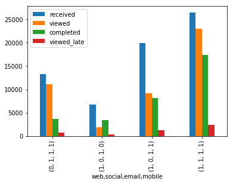

```python
# explore how offer channels affected the offers recieved, viewed, and completed
df2 = df_master[['web','social','email','mobile','received','viewed','completed','viewed_late']]
df2 = df2.groupby(['web','social','email','mobile']).sum()
df2.plot(kind='bar')
df2.head()
```

|  | received | viewed | completed | viewed_late |
| --- | --- | --- | --- | --- |
| web | 53175 | 34074 | 28787 | 4012 |
| social | 39802 | 34080 | 20959 | 3119 |
| email | 66501 | 45144 | 32444 | 4716 |
| mobile | 59775 | 43233 | 29058 | 4412 |

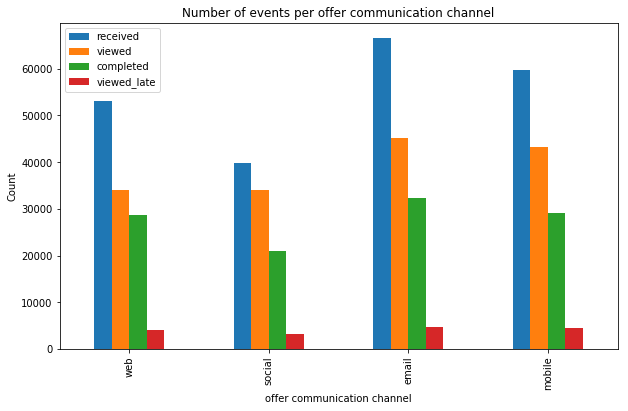

```python
#explore the impact of markeitng channels on the offer
df2 = pd.DataFrame(columns = ['received','viewed','completed','viewed_late'],index=['web','social','email','mobile'])
for index,row in df2.iterrows():
        row['received'] = df_master.loc[df_master[index]==1,'received'].sum()
        row['viewed'] = df_master.loc[df_master[index]==1,'viewed'].sum()
        row['completed'] = df_master.loc[df_master[index]==1,'completed'].sum()
        row['viewed_late'] = df_master.loc[df_master[index]==1,'viewed_late'].sum()

df2.plot(kind='bar',figsize=(10,6))
plt.title("Number of events per offer communication channel")
plt.xlabel("offer communication channel")
plt.ylabel("Count")

df2.head()
```

**reaction to different reward values**

| reward | received | viewed | completed | viewed_late |
| --- | --- | --- | --- | --- |
| 0 | 13300.0 | 9360.0 | 0.0 | 0.0 |
| 2 | 13283.0 | 8686.0 | 8914.0 | 1181.0 |
| 3 | 6655.0 | 5703.0 | 4886.0 | 676.0 |
| 5 | 19987.0 | 10374.0 | 11677.0 | 1650.0 |
| 10 | 13276.0 | 11021.0 | 6967.0 | 1209.0 |

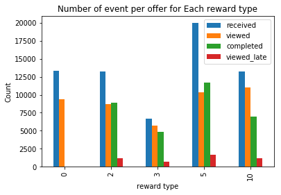

```python
#Explore the impact of reward values
df2 = df_master[['reward','received','viewed','completed','viewed_late']]
df2 = df2.groupby('reward').sum()
df2.plot(kind='bar')
plt.title("Number of event per offer for Each reward type")
plt.xlabel("reward type")
plt.ylabel("Count")
df2.head()
```

**reaction to different difficulty values**

| difficulty | received | viewed | completed | viewed_late |
| --- | --- | --- | --- | --- |
| 0 | 13300.0 | 9360.0 | 0.0 | 0.0 |
| 5 | 13261.0 | 8463.0 | 8291.0 | 1346.0 |
| 7 | 6655.0 | 5703.0 | 4886.0 | 676.0 |
| 10 | 26559.0 | 19707.0 | 15881.0 | 2390.0 |
| 20 | 6726.0 | 1911.0 | 3386.0 | 304.0 |

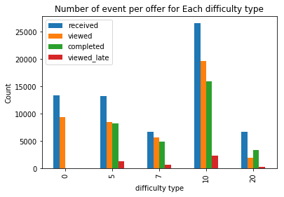

```python
#explore the impact of difficulty values
df2 = df_master[['difficulty','received','viewed','completed','viewed_late']]
df2 = df2.groupby('difficulty').sum()
df2.plot(kind='bar')
plt.title("Number of event per offer for Each difficulty type")
plt.xlabel("difficulty type")
plt.ylabel("Count")
df2.head()
```

**spendings of different age groups with & without offers**

```python
# add the money spent for offers and not for offers to the master dataframe
df_master['money_with_offers'] = df_master['customer_id'].apply(lambda x: money_spent_for_offers_dict[x])
df_master['money_without_offers'] = df_master['customer_id'].apply(lambda x: money_spent_without_offers_dict[x])
```

| age_group | money_with_offers | money_without_offers |
| --- | --- | --- |
| middle_age | 432350.71 | 267190.65 |
| old | 457443.18 | 291020.82 |
| young_adult | 183797.52 | 102889.26 |

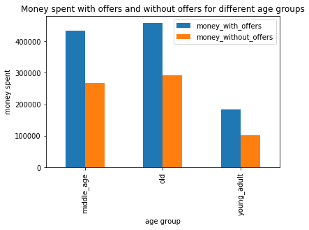

```python
# explore how different age groups spend money
df2 = df_master[['customer_id','age_group','money_with_offers','money_without_offers']]
df2.drop_duplicates(subset=['customer_id'],inplace=True)
df2.drop('customer_id',axis=1,inplace=True)
df2 = df2.groupby('age_group').sum()
df2.plot(kind='bar')
plt.title("Money spent with offers and without offers for different age groups")
plt.xlabel("age group")
plt.ylabel("money spent")
df2.head()
```

| gender | money_with_offers | money_without_offers |
| --- | --- | --- |
| F | 529155.06 | 334352.93 |
| M | 528100.46 | 316727.15 |
| O | 16335.89 | 10020.65 |

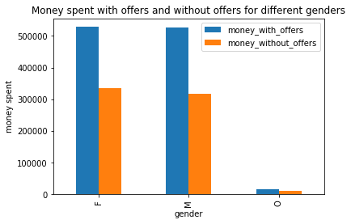

```python
# explore how different genders spend money
df2 = df_master[['customer_id','gender','money_with_offers','money_without_offers']]
df2.drop_duplicates(subset=['customer_id'],inplace=True)
df2.drop('customer_id',axis=1,inplace=True)
df2 = df2.groupby('gender').sum()
df2.plot(kind='bar')
plt.title("Money spent with offers and without offers for different genders")
plt.xlabel("gender")
plt.ylabel("money spent")
df2.head()
```

| income_range | money_with_offers | money_without_offers |
| --- | --- | --- |
| high | 118605.09 | 86877.24 |
| low | 407338.31 | 228053.74 |
| mid | 547648.01 | 346169.75 |

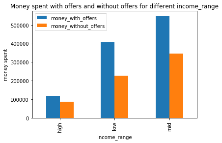

```python
#explore how different income ranges spend money
df2 = df_master[['customer_id','income_range','money_with_offers','money_without_offers']]
df2.drop_duplicates(subset=['customer_id'],inplace=True)
df2.drop('customer_id',axis=1,inplace=True)
df2 = df2.groupby('income_range').sum()
df2.plot(kind='bar')
plt.title("Money spent with offers and without offers for different income_range")
plt.xlabel("income_range")
plt.ylabel("money spent")
df2.head()
```

| customer_type | money_with_offers | money_without_offers |
| --- | --- | --- |
| loyal | 46432.72 | 22284.28 |
| new | 248309.12 | 157374.66 |
| regular | 778849.57 | 481441.79 |

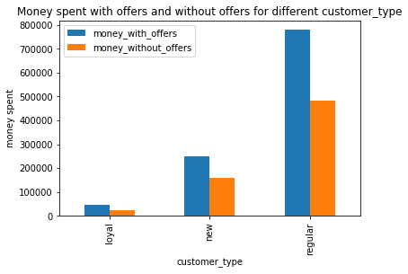

```python
#explore how different customer types spend money
df2 = df_master[['customer_id','customer_type','money_with_offers','money_without_offers']]
df2.drop_duplicates(subset=['customer_id'],inplace=True)
df2.drop('customer_id',axis=1,inplace=True)
df2 = df2.groupby('customer_type').sum()
df2.plot(kind='bar')
plt.title("Money spent with offers and without offers for different customer_type")
plt.xlabel("customer_type")
plt.ylabel("money spent")
df2.head()
```

## Data Modelling:

I will leave only the fields that I believe are relevant to the predication. I will also have to convert some of the fields to be in number format.

Based on the details we have the predicted fields should be viewed and completed to tell me wether an offer would be viewed and completed or not.

```python
df_master_backup = df_master.copy()
print(df_master.shape)
df_master.head()
```

```
(55222, 22)
```

|  | customer_id | offer_id | received | viewed | completed | viewed_late | gender | age | age_group | income | ... | days_as_member | customer_type | offer_type | difficulty | reward | duration_hours | web | email | mobile | social |
| --- | --- | --- | --- | --- | --- | --- | --- | --- | --- | --- | --- | --- | --- | --- | --- | --- | --- | --- | --- | --- | --- |
| 0 | 7997 | 7.0 | 1.0 | 1.0 | 1.0 | 0.0 | F | 75 | old | 100000.0 | ... | 1255 | regular | bogo | 5 | 5 | 168 | 1 | 1 | 1 | 0 |
| 1 | 15044 | 3.0 | 1.0 | 1.0 | 0.0 | 0.0 | M | 68 | old | 70000.0 | ... | 903 | new | discount | 10 | 2 | 168 | 1 | 1 | 1 | 0 |
| 2 | 3729 | 9.0 | 2.0 | 2.0 | 2.0 | 0.0 | M | 65 | old | 53000.0 | ... | 979 | new | bogo | 5 | 5 | 120 | 1 | 1 | 1 | 1 |
| 3 | 3060 | 4.0 | 1.0 | 0.0 | 0.0 | 0.0 | M | 58 | middle_age | 51000.0 | ... | 1069 | new | informational | 0 | 0 | 96 | 1 | 1 | 1 | 0 |
| 4 | 11411 | 1.0 | 1.0 | 1.0 | 0.0 | 0.0 | F | 61 | old | 57000.0 | ... | 1130 | regular | discount | 20 | 5 | 240 | 1 | 1 | 0 | 0 |

5 rows × 22 columns

```python
df_master = df_master_backup.copy()
```

```python
#drope some fields that I will not use in the modelling
df_master.drop(['age','income','customer_id','days_as_member','year_joined'],axis=1,inplace=True)
# df_master.drop('customer_id',axis=1,inplace=True)
#convert gender to numbers M - 1 F -2 and O - 3
df_master['gender'] = df_master['gender'].apply(lambda x: 1 if x == 'M' else (2 if x == 'F' else 3))
#convert age groups to number format young_adult=1 middle_age=2 and old=3
df_master['age_group'] = df_master['age_group'].apply(lambda x: 1 if x == 'young_adult'
                                                      else (2 if x == 'middle_age' else 3))
#convert income range to number format low = 1 mid=2 and high =3
df_master['income_range'] = df_master['income_range'].apply(lambda x: 1 if x == 'low'
                                                            else (2 if x == 'mid' else 3))
#convert customer type to number format new = 1 regular =2 loyal = 3
df_master['customer_type'] = df_master['customer_type'].apply(lambda x: 1 if x == 'new'
                                                              else (2 if x == 'regular' else 3))
#conver offer type to number format bogo = 1 discount = 2 informational =3
df_master['offer_type'] = df_master['offer_type'].apply(lambda x: 1 if x == 'bogo'
                                                           else (2 if x == 'discount' else 3))
#scale the duration hours reward and difficulty values since they are widley distributed
scaler = MinMaxScaler()
features = ['duration_hours', 'reward', 'difficulty']
# features = ['age','income','days_as_member','duration_hours','reward','difficulty','money_with_offers',
#            'money_without_offers']
df_master[features] = scaler.fit_transform(df_master[features])
df_master.head()
```

|  | offer_id | received | viewed | completed | viewed_late | gender | age_group | income_range | customer_type | offer_type | difficulty | reward | duration_hours | web | email | mobile | social |
| --- | --- | --- | --- | --- | --- | --- | --- | --- | --- | --- | --- | --- | --- | --- | --- | --- | --- |
| 0 | 7.0 | 1.0 | 1.0 | 1.0 | 0.0 | 2 | 3 | 3 | 2 | 1 | 0.25 | 0.5 | 0.571429 | 1 | 1 | 1 | 0 |
| 1 | 3.0 | 1.0 | 1.0 | 0.0 | 0.0 | 1 | 3 | 2 | 1 | 2 | 0.50 | 0.2 | 0.571429 | 1 | 1 | 1 | 0 |
| 2 | 9.0 | 2.0 | 2.0 | 2.0 | 0.0 | 1 | 3 | 1 | 1 | 1 | 0.25 | 0.5 | 0.285714 | 1 | 1 | 1 | 1 |
| 3 | 4.0 | 1.0 | 0.0 | 0.0 | 0.0 | 1 | 2 | 1 | 1 | 3 | 0.00 | 0.0 | 0.142857 | 1 | 1 | 1 | 0 |
| 4 | 1.0 | 1.0 | 1.0 | 0.0 | 0.0 | 2 | 3 | 1 | 2 | 2 | 1.00 | 0.5 | 1.000000 | 1 | 1 | 0 | 0 |

```python
#prepare the x values for the prediction model
x = df_master.drop(['viewed','completed'],axis=1)
#defind the values to be predicted
y = df_master[['viewed','completed']]
#split the values to training and testing
x_train,x_test,y_train,y_test = train_test_split(x,y,random_state=42)
```

```python
'''
prints the classification report for the predicted value vs test value.
arguments:
    classification_name: name of the classifier
    y_pred: the predicted value
    y_test: the test value

'''
def print_scoring_report(classification_name,y_pred,y_test):
    labels = ['viewed','completed']
    y_test2 = np.array(y_test)
    y_pred2 = np.array(y_pred)
    class_dict={}

    for label in range(len(labels)):
        y_test_label = y_test2[:, label]
        y_pred_label = y_pred2[:, label]
        class_dict[labels[label]] = classification_report(y_pred=y_pred_label, y_true=y_test_label)
        print("The accuracy for label {} using {} is: {}".format(labels[label],classification_name,
                                                                    accuracy_score(y_test_label,y_pred_label)))


    for label, matrix in class_dict.items():
        print("Classificaiton report for label {} using {}:".format(label,classification_name))
        print(matrix)
```

```python
'''
create a multioutput classifier and then fit it and predict the y value.
finally print the score of the classifier.
arguments:
    classifier_type: pass the classifier that you are using in the multioutput classifier
output:
    y_pred: the predicted y value

'''
def predict_values(classifier_type):
    classifier = MultiOutputClassifier(estimator=classifier_type,n_jobs=-1)
    classifier.fit(x_train,y_train)
    y_pred = classifier.predict(x_test)
#     print("The score of the classifier is ", classifier.score(x_test,y_test))
#     print("The score of the classifier on training data is ", classifier.score(x_train,y_train))
    return y_pred
```

```python
#Decision Tree Classifier
dt = DecisionTreeClassifier(max_features='auto')
y_pred = predict_values(dt)
print_scoring_report('DecisionTreeClassifier',y_pred,y_test)
```

```
The accuracy for label viewed using DecisionTreeClassifier is: 0.7961031435607707
The accuracy for label completed using DecisionTreeClassifier is: 0.7482254092423584
Classificaiton report for label viewed using DecisionTreeClassifier:
             precision    recall  f1-score   support

        0.0       0.68      0.70      0.69      4017
        1.0       0.86      0.83      0.84      8391
        2.0       0.79      0.86      0.82      1280
        3.0       0.75      0.73      0.74       111
        4.0       1.00      0.20      0.33         5
        5.0       0.00      0.00      0.00         2

avg / total       0.80      0.80      0.80     13806

Classificaiton report for label completed using DecisionTreeClassifier:
             precision    recall  f1-score   support

        0.0       0.77      0.77      0.77      6843
        1.0       0.74      0.74      0.74      5928
        2.0       0.66      0.69      0.67       950
        3.0       0.57      0.48      0.52        82
        4.0       0.00      0.00      0.00         3

avg / total       0.75      0.75      0.75     13806
```

```python
#Gaussian naive bayes
gnb = GaussianNB()
y_pred = predict_values(gnb)
print_scoring_report('Gaussian Naive Bayes ',y_pred,y_test)
```

```
The accuracy for label viewed using Gaussian Naive Bayes  is: 0.7687237433000145
The accuracy for label completed using Gaussian Naive Bayes  is: 0.5677241778936695
Classificaiton report for label viewed using Gaussian Naive Bayes :
             precision    recall  f1-score   support

        0.0       0.75      0.44      0.56      4017
        1.0       0.79      0.90      0.84      8391
        2.0       0.69      0.94      0.80      1280
        3.0       0.63      0.95      0.76       111
        4.0       0.62      1.00      0.77         5
        5.0       0.00      0.00      0.00         2

avg / total       0.77      0.77      0.75     13806

Classificaiton report for label completed using Gaussian Naive Bayes :
             precision    recall  f1-score   support

        0.0       0.54      1.00      0.70      6843
        1.0       1.00      0.12      0.21      5928
        2.0       0.84      0.26      0.40       950
        3.0       0.74      0.52      0.61        82
        4.0       0.30      1.00      0.46         3

avg / total       0.76      0.57      0.47     13806
```

```python
#Logistic regresssion:
lr = LogisticRegression()
y_pred = predict_values(lr)
print_scoring_report('Gaussian Naive Bayes ',y_pred,y_test)
```

```
The accuracy for label viewed using Gaussian Naive Bayes  is: 0.7739388671592061
The accuracy for label completed using Gaussian Naive Bayes  is: 0.734318412284514
Classificaiton report for label viewed using Gaussian Naive Bayes :
             precision    recall  f1-score   support

        0.0       0.65      0.66      0.65      4017
        1.0       0.84      0.83      0.84      8391
        2.0       0.73      0.84      0.78      1280
        3.0       0.00      0.00      0.00       111
        4.0       0.00      0.00      0.00         5
        5.0       0.00      0.00      0.00         2

avg / total       0.77      0.77      0.77     13806

Classificaiton report for label completed using Gaussian Naive Bayes :
             precision    recall  f1-score   support

        0.0       0.78      0.73      0.75      6843
        1.0       0.72      0.76      0.74      5928
        2.0       0.59      0.65      0.62       950
        3.0       0.00      0.00      0.00        82
        4.0       0.00      0.00      0.00         3

avg / total       0.73      0.73      0.73     13806
```

```python
#K_nearest neighbor
knn = KNeighborsClassifier()
y_pred = predict_values(knn)
print_scoring_report('K-Nearest Neighbor',y_pred,y_test)
```

```
The accuracy for label viewed using K-Nearest Neighbor is: 0.7750253512965377
The accuracy for label completed using K-Nearest Neighbor is: 0.7225843836013327
Classificaiton report for label viewed using K-Nearest Neighbor:
             precision    recall  f1-score   support

        0.0       0.66      0.64      0.65      4017
        1.0       0.83      0.84      0.83      8391
        2.0       0.77      0.85      0.81      1280
        3.0       0.69      0.38      0.49       111
        4.0       0.00      0.00      0.00         5
        5.0       0.00      0.00      0.00         2

avg / total       0.77      0.78      0.77     13806

Classificaiton report for label completed using K-Nearest Neighbor:
             precision    recall  f1-score   support

        0.0       0.76      0.73      0.74      6843
        1.0       0.70      0.74      0.72      5928
        2.0       0.66      0.61      0.64       950
        3.0       0.65      0.37      0.47        82
        4.0       0.00      0.00      0.00         3

avg / total       0.72      0.72      0.72     13806
```

```python
#Support vector classifier
svm = SVC()
y_pred = predict_values(svm)
print_scoring_report('Support Vector classifier',y_pred,y_test)
```

```
The accuracy for label viewed using Support Vector classifier is: 0.7940750398377517
The accuracy for label completed using Support Vector classifier is: 0.7494567579313341
Classificaiton report for label viewed using Support Vector classifier:
             precision    recall  f1-score   support

        0.0       0.66      0.70      0.68      4017
        1.0       0.86      0.83      0.84      8391
        2.0       0.82      0.85      0.84      1280
        3.0       0.67      0.93      0.78       111
        4.0       0.00      0.00      0.00         5
        5.0       0.00      0.00      0.00         2

avg / total       0.80      0.79      0.80     13806

Classificaiton report for label completed using Support Vector classifier:
             precision    recall  f1-score   support

        0.0       0.76      0.78      0.77      6843
        1.0       0.75      0.72      0.73      5928
        2.0       0.65      0.77      0.71       950
        3.0       0.59      0.77      0.67        82
        4.0       0.00      0.00      0.00         3

avg / total       0.75      0.75      0.75     13806
```

```python
from sklearn.neural_network import MLPClassifier

mlp = MLPClassifier()
y_pred = predict_values(mlp)
print_scoring_report('MLP classifier',y_pred,y_test)
```

```
The accuracy for label viewed using MLP classifier is: 0.7844415471534115
The accuracy for label completed using MLP classifier is: 0.7542372881355932
Classificaiton report for label viewed using MLP classifier:
             precision    recall  f1-score   support

        0.0       0.62      0.83      0.71      4017
        1.0       0.90      0.76      0.82      8391
        2.0       0.84      0.84      0.84      1280
        3.0       0.76      0.80      0.78       111
        4.0       0.00      0.00      0.00         5
        5.0       0.00      0.00      0.00         2

avg / total       0.81      0.78      0.79     13806

Classificaiton report for label completed using MLP classifier:
             precision    recall  f1-score   support

        0.0       0.78      0.76      0.77      6843
        1.0       0.74      0.74      0.74      5928
        2.0       0.66      0.76      0.71       950
        3.0       0.57      0.79      0.66        82
        4.0       0.00      0.00      0.00         3

avg / total       0.76      0.75      0.75     13806
```